# STAA57 W19 - Project Proposal

Team 12

#### Research Questions

1. Specify which questions you will address.

The initial question of “Is university education worth it?” was rather broad so we wanted to find a clear concise way of simplifying it while still trying our best to answer it. One of the major factors about post secondary education in general is to try to find a better job than if you were to have skipped out on it entirely. So we wanted to delve deeper into the world of if getting a degree actually affects how much money you end up making in the future. The question we will be focusing our research on will be “Does a university degree actually translate to better pay in the future?” and then hopefully we can investigate “How fast will you be able to recoup your investment in post secondary education?”.

2. Specify your data analysis plan

In our analysis we will be using a combination of education data and employment data. A good place to start will be to start looking at data that explains or shows how much people with all kinds of education backgrounds make. So we could filter the observations in the data set we use to see which individuals did receive a university degree and the ones that didn’t. From there we could then look at the average of the salaries of the university graduates and compare it to the average of the salaries of workers who did not graduate and compare the values and try to draw a conclusion.We can also look at the employment of university graduates versus those who did not attend university to see if those individuals have higher employment. So from there, we can look calculate the unemployment rate of university graduates (doing the relevant calculations of course) and compare it to the unemployment of those who did not go to university and try to further support our argument.

#### Data Description

3. Specify your data sources and data collection methods.

Since we want to measure the difference on income and unemployment rate between people who graduated from university and people who not, we want to find the employment condition of all these people in the same year. Based on three key words “education”, “income” and “unemployment” we found two data source we want to use.

The first one is the National Graduates Survey 2013 (for class of 2009/2010), which include detailed information about the employment condition of people who should graduate at 2009 or 2010, aiming to see how postsecondary program helps people on their career. The data of NGS(2013) is collected through questionnaire, the target population is the graduates from Canadian public postsecondary education institutions (universities, colleges, trade schools) who graduated or completed the requirements for degrees, diplomas or certificates during the reference school year(2009 & 2010). The potential issue for this dataset are Non-response bias, as there are some people fail to answer some of the questions and these questioned have only “not stated”, and also there is bias caused by some automatic editing of the survey, for example, for income, if the input for hourly salary is too high this will change to annual salary, while those in between or some extreme value may be classified wrong, causing inaccuracy.

The second one is the Country Income Survey 2013. As NGS doesn’t contain the data for people who do not complete post secondary education, we want to use this data as to make comparison. The target population is all individuals in Canada, with few exclusion lower than 3% of population. The data mainly collected by asking one knowledgeable household member for all members’ information in one household. The main bias are the coverage bias and the lack of accuracy due to the way data is collect(collected through only one people each household).

Reference 1(NGS): http://www23.statcan.gc.ca/imdb/p2SV.pl?Function=getSurvey&Id=122604

Questionnaire of reference 1: http://www23.statcan.gc.ca/imdb/p3Instr.pl?Function=assembleInstr&a=1&&lang=en&Item_Id=150151

Reference 2(CIS): http://www23.statcan.gc.ca/imdb/p2SV.pl?Function=getSurvey&SDDS=5200

Questionnaire of reference 2: http://www23.statcan.gc.ca/imdb/p3Instr.pl?Function=assembleInstr&a=1&&lang=en&Item_Id=424634

4. Identify the variables/observations you will use for your analysis.

> **National Graduate Survey (2013)**: The following variables are key in analyzing our data. They will be used to filter, sort, and correlate data accordingly.
> - CNDPERSP, total personal income from all sources in 2013
> - JOBINCP, gross annual earnings from 2013
> - DBTALGRD, debt of all loans at time of graduation (2009/10)
> - DBTALINT, debt of all loans at time of interview (2013)
> - DBTGSGRD, debt of government sponsored student loans at time of graduation (2009/2010)
> - DBTGSINT, debt of government sponsored student loans at time of interview (2013)
> - LFSTAT, labour force status in 2013 reference week

> **Canadian Income Survey (2013)**: Hundreds of variables are provided, but the variables key to our analysis are listed below.
> - AGEGP, person’s age group as of December 31 of 2013
> - HLEV2G, highest level of education of person
> - STUDFTP, attended school/college/CEGEP/university during 2013
> - EFATINC, after-tax income

#### Getting Started

5. Load data into R.

```r
ngs = read.csv("ngs.csv")
cis = read.csv("cis.csv")
ngs %>% head
```

|  | CASEID | pumfid | regonid | de_q03p | de_q05ap | de_q30 | de_q31 | de_q32 | de_q33p | msncq01p | sex_q01 | pr_q05 | pr_q07 | pr_q08a | pr_q08b | pr_q08c | pr_q08ep | pr_q08g | pr_q08jp | pr_q09 | pr_q12b | pr_q12d | pr_q13p | pr_q17a | pr_q17b | pr_q17c | pr_q17d | pr_q17e | pr_q17f | … |
| --- | --- | --- | --- | --- | --- | --- | --- | --- | --- | --- | --- | --- | --- | --- | --- | --- | --- | --- | --- | --- | --- | --- | --- | --- | --- | --- | --- | --- | --- | --- |
| 1 | 1003 | 1003 | 3 | 1 | 1 | 2 | 2 | 2 | 2 | 1 | 2 | 2 | 1 | 6 | 6 | 6 | 6 | 6 | 6 | 2 | 2 | 2 | 1 | 1 | 1 | 3 | 1 | 2 | 3 | … |
| 2 | 1010 | 1010 | 4 | 0 | 1 | 2 | 2 | 2 | 2 | 1 | 1 | 7 | 2 | 1 | 2 | 2 | 2 | 2 | 2 | 2 | 2 | 2 | 1 | 2 | 2 | 1 | 2 | 3 | 1 | … |
| 3 | 1015 | 1015 | 2 | 0 | 3 | 2 | 2 | 2 | 2 | 2 | 1 | 2 | 1 | 6 | 6 | 6 | 6 | 6 | 6 | 2 | 2 | 2 | 1 | 2 | 1 | 2 | 1 | 2 | 1 | … |
| 4 | 1018 | 1018 | 1 | 1 | 1 | 2 | 2 | 2 | 2 | 1 | 2 | 1 | 1 | 6 | 6 | 6 | 6 | 6 | 6 | 2 | 2 | 2 | 1 | 1 | 1 | 3 | 2 | 2 | 1 | … |
| 5 | 1019 | 1019 | 1 | 1 | 1 | 2 | 2 | 2 | 2 | 1 | 1 | 1 | 1 | 6 | 6 | 6 | 6 | 6 | 6 | 2 | 1 | 2 | 1 | 1 | 1 | 2 | 2 | 1 | 2 | … |
| 6 | 1021 | 1021 | 4 | 0 | 1 | 2 | 2 | 2 | 2 | 2 | 1 | 2 | 1 | 6 | 6 | 6 | 6 | 6 | 6 | 2 | 2 | 2 | 1 | 2 | 2 | 3 | 2 | 1 | 3 | … |

```r
cis %>% head
```

|  | CASEID | lang | type | q13 | q14 | q14a | q15 | q16 | q17 | q41 | q12 | q18 | q19 | q20 | q21 | q23 | q24 | q25 | q26 | q27 | q28 | q6pre | q7m1 | q7m2 | q7m3 | q7m4 | q8 | q9m1 | q9m2 | … |
| --- | --- | --- | --- | --- | --- | --- | --- | --- | --- | --- | --- | --- | --- | --- | --- | --- | --- | --- | --- | --- | --- | --- | --- | --- | --- | --- | --- | --- | --- | --- |
| 1 | 1 | 1 | 2 | 1 | 5 | 4 | 1 | 2 | 2 | 2 | 2 | 1 | 50 | 1 | 50 | 1 | 1 | 2 | 3 | 2 | 1 | 2 | NA | NA | NA | NA | 3 | NA | NA | … |
| 2 | 2 | 1 | 1 | 1 | 7 | 3 | 2 | 1 | 2 | 2 | 2 | 1 | 20 | 1 | 20 | 2 | NA | 1 | 3 | 2 | 2 | 1 | 6 | NA | NA | NA | 2 | 1 | NA | … |
| 3 | 3 | 2 | NA | 3 | 1 | 5 | 1 | 1 | 2 | 2 | 2 | 2 | NA | 1 | 16 | 2 | NA | 1 | 1 | 2 | 2 | 2 | NA | NA | NA | NA | 2 | 3 | NA | … |
| 4 | 4 | 1 | NA | 1 | 98 | 4 | 3 | 2 | 1 | 2 | 2 | 2 | NA | 2 | NA | NA | 9 | 1 | 1 | 2 | 2 | 1 | 1 | 2 | NA | NA | 3 | NA | NA | … |
| 5 | 5 | 2 | 5 | 1 | 8 | 3 | 3 | 1 | 2 | 2 | 2 | 1 | 8 | 1 | 8 | 2 | NA | 2 | 1 | 2 | 2 | 2 | NA | NA | NA | NA | 3 | NA | NA | … |
| 6 | 6 | 1 | 2 | 3 | 5 | 3 | 2 | 1 | 2 | 2 | 2 | 1 | 30 | 1 | 20 | 1 | NA | 1 | 1 | 2 | 1 | 2 | NA | NA | NA | NA | 2 | 1 | NA | … |

6. Explore data

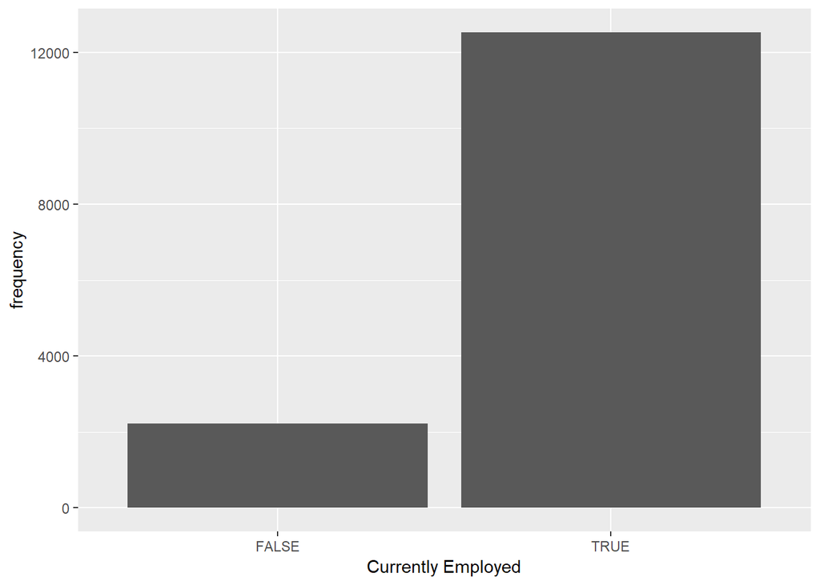

```r
ngs %>% mutate(lfstat = (lfstat == 1)) %>%
  ggplot(aes(lfstat)) + geom_bar() + xlab("Currently Employed") + ylab("frequency")
```

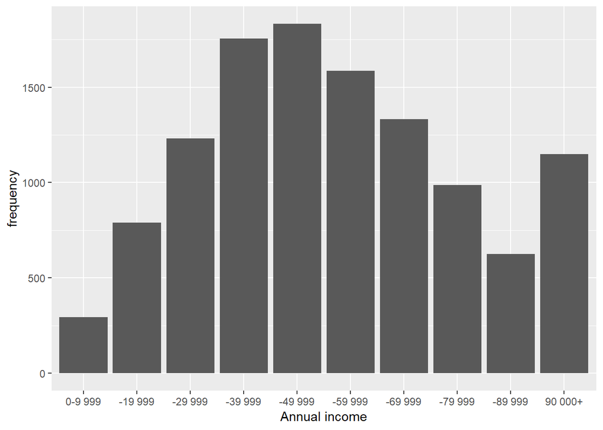

```r
ngs %>% filter(lfstat == 1, jobincp != 99 & jobincp != 96) %>% mutate(jobincp = factor(jobincp, labels = c("0-9 999", "-19 999", "-29 999", "-39 999", "-49 999", "-59 999", "-69 999", "-79 999", "-89 999", "90 000+"))) %>%
  ggplot(aes(jobincp)) + geom_bar() + xlab("Annual income") + ylab("frequency")
```

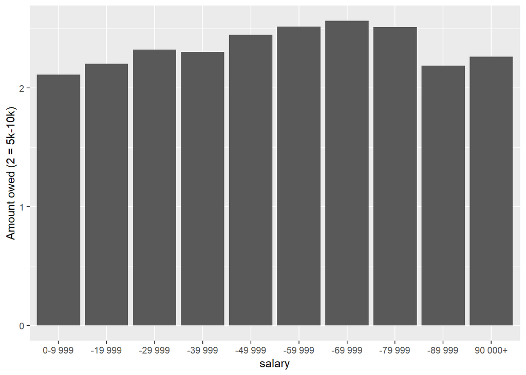

```r
ngs %>% filter(lfstat == 1, jobincp != 99 & jobincp != 96, dbtalgrd != 6 & dbtalgrd != 9) %>%
  mutate(jobincp = factor(jobincp, labels = c("0-9 999", "-19 999", "-29 999", "-39 999", "-49 999", "-59 999", "-69 999", "-79 999", "-89 999", "90 000+"))) %>%
  group_by(jobincp) %>% summarise(owed = mean(dbtalgrd)) %>%
  ggplot(aes (jobincp, owed)) + geom_histogram(stat = "identity") + ylab("Amount owed (2 = 5k-10k)") + xlab("salary")
```